# DC circuits

In the circuit shown in the figure, the Thevenin resistance seen from $PQ$ is $144\,\Omega$.

1. Find $R_3$.
2. Find $V_{Th}$ as seen from $PQ$.
3. If a resistance $R_L=100\,\Omega$ is connected between $P$ and $Q$, what current will it draw?

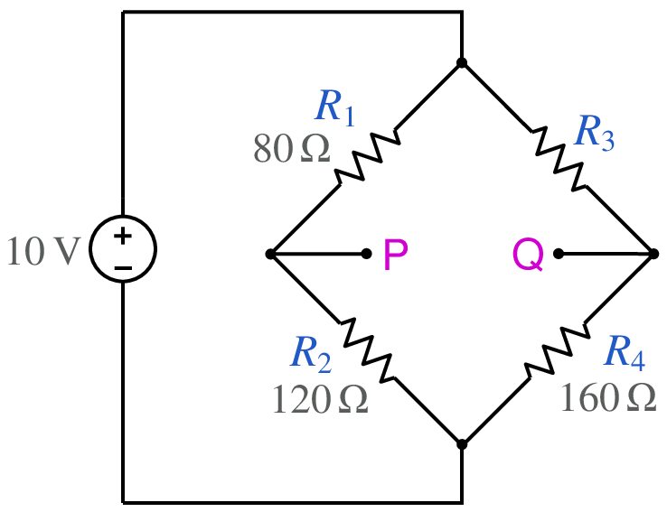

```python
from IPython.display import Image
Image(filename =r'dc_circuit_12_fig_1.png', width=250)
```

```python
# run this cell to view the circuit file.
%pycat dc_circuit_12_orig.in
```

We now replace the string \$R3 with the value of our choice by running the python script given below. It takes an existing circuit file `dc_circuit_12_orig.in` and produces a new circuit file `dc_circuit_12.in`, after replacing \$R3 with the value of our choice.

```python
import gseim_calc as calc
s_R3 = '500' # to be changed by user
l = [
  ('$R3', s_R3),
]
calc.replace_strings_1("dc_circuit_12_orig.in", "dc_circuit_12.in", l)
print('dc_circuit_12.in is ready for execution')
```

```
dc_circuit_12.in is ready for execution
```

**Execute the following cell to run GSEIM on dc_circuit_12.in.**

```python
import os
import dos_unix
# uncomment for windows:
#dos_unix.d2u("dc_circuit_12.in")
os.system('run_gseim dc_circuit_12.in')
```

```
Circuit: filename = dc_circuit_12.in
main: i_solve = 1
main: i_solve = 2
GSEIM: Program completed.
```

```
0
```

The circuit file (`dc_circuit_12.in`) is created in the same directory as that used for launching Jupyter notebook. The last step (i.e., running `GSEIM` on `dc_circuit_12.in`) creates the data files `dc_circuit_12_1.dat`, etc. in the same directory. We can now use the python code below to compute and display the quantities of interest.

```python
import numpy as np
import matplotlib.pyplot as plt
import gseim_calc as calc
from setsize import set_size

slv = calc.slv("dc_circuit_12.in")

i_slv = 0
i_out = 0
filename = slv.l_filename_all[i_slv][i_out]
print('filename:', filename)
u = np.loadtxt(filename)
VRL = slv.get_scalar_double(i_slv, i_out, "VRL", u)
IRL = slv.get_scalar_double(i_slv, i_out, "IRL", u)

Isc = IRL

i_slv = 1
i_out = 0
filename = slv.l_filename_all[i_slv][i_out]
print('filename:', filename)
u = np.loadtxt(filename)
VRL = slv.get_scalar_double(i_slv, i_out, "VRL", u)
IRL = slv.get_scalar_double(i_slv, i_out, "IRL", u)

Voc = VRL
RTh = Voc/Isc

i_slv = 2
i_out = 0
filename = slv.l_filename_all[i_slv][i_out]
print('filename:', filename)
u = np.loadtxt(filename)
VRL = slv.get_scalar_double(i_slv, i_out, "VRL", u)
IRL = slv.get_scalar_double(i_slv, i_out, "IRL", u)

s_format = "%11.4E"
calc.print_double_1('Isc', Isc, s_format)
calc.print_double_1('Voc', Voc, s_format)
calc.print_double_1('RTh', RTh, s_format)
calc.print_double_1('Current through RL for RL = 100 ohm', IRL, s_format)
```

```
filename: dc_circuit_12_1.dat
filename: dc_circuit_12_2.dat
filename: dc_circuit_12_3.dat
Isc:  2.1132E-02
Voc:  3.5758E+00
RTh:  1.6921E+02
Current through RL for RL = 100 ohm:  1.3282E-02
```

This notebook was contributed by **Prof. M. B. Patil**, IIT Bombay. He may be contacted at mbpatil@ee.iitb.ac.in.